# Lab 1

## Lab 4: Coffee Lovers Unite

### 1. Scrape the Location Counts

Starbucks

```python
import requests
response = requests.get("https://www.menuism.com/restaurant-locations/starbucks-coffee-39564")
```

```python
from bs4 import BeautifulSoup
soup = BeautifulSoup(response.content, "html.parser")
```

```python
table = soup.find_all('li',{'class':""})
len(table) # there are 5 major regions that we need to scrape data from so we need to use the location-list-header
```

```
92
```

```python
import re
import pandas as pd

# initialize an empty list
rows = []

# iterate over all rows in the faculty table
for coffee_location in soup.find_all('li',{'class':""}):
    a_tag = coffee_location.find("a")
    if a_tag:
        text = a_tag.get_text(strip=True)

        # use regex to extract state name and number of locations

        match = re.match(r"(.+) Starbucks Coffee locations \((\d+)\)", text) # use \( to excape the parenteses
        # https://www.guru99.com/python-regular-expressions-complete-tutorial.html
        if match:
            state_name = match.group(1)
            num_locations = int(match.group(2))

            # append this data
            rows.append({
                "State Names": state_name,
                "Store Locations": num_locations
            })

# create a DataFrame
pd.DataFrame(rows)
```

|  | State Names | Store Locations |
| --- | --- | --- |
| 0 | Alaska | 24 |
| 1 | Alabama | 73 |
| 2 | Arkansas | 33 |
| 3 | Arizona | 279 |
| 4 | California | 2362 |
| 5 | Colorado | 371 |
| 6 | Connecticut | 107 |
| 7 | District of Columbia | 72 |
| 8 | Delaware | 20 |
| 9 | Florida | 616 |
| 10 | Georgia | 248 |
| 11 | Hawaii | 72 |
| 12 | Iowa | 49 |
| 13 | Idaho | 57 |
| 14 | Illinois | 455 |
| 15 | Indiana | 193 |
| 16 | Kansas | 65 |
| 17 | Kentucky | 69 |
| 18 | Louisiana | 76 |
| 19 | Massachusetts | 208 |
| 20 | Maryland | 212 |
| 21 | Maine | 22 |
| 22 | Michigan | 196 |
| 23 | Minnesota | 140 |
| 24 | Missouri | 118 |
| 25 | Mississippi | 23 |
| 26 | Montana | 17 |
| 27 | North Carolina | 181 |
| 28 | North Dakota | 15 |
| 29 | Nebraska | 30 |
| 30 | New Hampshire | 22 |
| 31 | New Jersey | 154 |
| 32 | New Mexico | 56 |
| 33 | Nevada | 188 |
| 34 | New York | 492 |
| 35 | Ohio | 266 |
| 36 | Oklahoma | 62 |
| 37 | Oregon | 279 |
| 38 | Pennsylvania | 279 |
| 39 | Rhode Island | 21 |
| 40 | South Carolina | 65 |
| 41 | South Dakota | 14 |
| 42 | Tennessee | 126 |
| 43 | Texas | 720 |
| 44 | Utah | 59 |
| 45 | Virginia | 300 |
| 46 | Vermont | 6 |
| 47 | Washington | 634 |
| 48 | Wisconsin | 119 |
| 49 | West Virginia | 13 |
| 50 | Wyoming | 16 |
| 51 | County Dublin | 1 |
| 52 | England | 1 |
| 53 | Greater London | 3 |
| 54 | Surrey | 1 |
| 55 | Madrid | 1 |
| 56 | British Columbia | 1 |
| 57 | Ontario | 1 |

Dunkin’ Donuts

```python
import requests
response = requests.get("https://www.menuism.com/restaurant-locations/dunkin-donuts-181624n")
from bs4 import BeautifulSoup
soup = BeautifulSoup(response.content, "html.parser")
soup
```

[output not shown]

[output cut: 873 more lines]

[output not shown]

```python
table = soup.find_all('li',{'class':""})
len(table)
```

```
82
```

```python
import re
import pandas as pd

# initialize an empty list
rows = []

# iterate over all rows in the faculty table
for coffee_location in table:
    a_tag = coffee_location.find("a")
    if a_tag:
        text = a_tag.get_text(strip=True)

        # use regex to extract state name and number of locations

        match = re.match(r"(.+) Dunkin' Donuts locations \((\d+)\)", text) # use \( to excape the parenteses
        # https://www.guru99.com/python-regular-expressions-complete-tutorial.html
        if match:
            state_name = match.group(1)
            num_locations = int(match.group(2))

            # append this data
            rows.append({
                "State Names": state_name,
                "Store Locations": num_locations
            })

# create a DataFrame
pd.DataFrame(rows)
```

|  | State Names | Store Locations |
| --- | --- | --- |
| 0 | Alabama | 1 |
| 1 | Arkansas | 11 |
| 2 | Arizona | 74 |
| 3 | California | 46 |
| 4 | Colorado | 5 |
| 5 | Connecticut | 406 |
| 6 | District of Columbia | 15 |
| 7 | Delaware | 57 |
| 8 | Florida | 654 |
| 9 | Georgia | 147 |
| 10 | Hawaii | 1 |
| 11 | Iowa | 14 |
| 12 | Illinois | 579 |
| 13 | Indiana | 51 |
| 14 | Kansas | 12 |
| 15 | Kentucky | 34 |
| 16 | Louisiana | 5 |
| 17 | Massachusetts | 1101 |
| 18 | Maryland | 201 |
| 19 | Maine | 102 |
| 20 | Michigan | 91 |
| 21 | Minnesota | 6 |
| 22 | Missouri | 21 |
| 23 | Mississippi | 3 |
| 24 | North Carolina | 63 |
| 25 | Nebraska | 9 |
| 26 | New Hampshire | 185 |
| 27 | New Jersey | 477 |
| 28 | New Mexico | 7 |
| 29 | Nevada | 26 |
| 30 | New York | 1022 |
| 31 | Ohio | 116 |
| 32 | Oklahoma | 6 |
| 33 | Oregon | 1 |
| 34 | Pennsylvania | 402 |
| 35 | Rhode Island | 142 |
| 36 | South Carolina | 15 |
| 37 | Tennessee | 55 |
| 38 | Texas | 93 |
| 39 | Utah | 7 |
| 40 | Virginia | 147 |
| 41 | Vermont | 34 |
| 42 | Washington | 2 |
| 43 | Wisconsin | 30 |
| 44 | West Virginia | 5 |
| 45 | Prince Edward Island | 2 |
| 46 | Quebec | 4 |

Peet’s Coffee & Tea

```python
import requests
response = requests.get("https://www.menuism.com/restaurant-locations/peets-coffee-tea-84051")
from bs4 import BeautifulSoup
soup = BeautifulSoup(response.content, "html.parser")
```

```python
table_peets = soup.find_all('li',{'class':""})
len(table_peets)
```

```
44
```

```python
import re
import pandas as pd

# initialize an empty list
rows = []

# iterate over all rows in the faculty table
for coffee_location in table:
    a_tag = coffee_location.find("a")
    if a_tag:
        text = a_tag.get_text(strip=True)

        # use regex to extract state name and number of locations

        match = re.match(r"(.+) Peet's Coffee & Tea locations \((\d+)\)", text) # use \( to excape the parenteses
        # https://www.guru99.com/python-regular-expressions-complete-tutorial.html
        if match:
            state_name = match.group(1)
            num_locations = int(match.group(2))

            # append this data
            rows.append({
                "State Names": state_name,
                "Store Locations": num_locations
            })

# create a DataFrame
Pf= pd.DataFrame(rows)

Pf
```

[output not shown]

Tim Horton’s

```python
import requests
response = requests.get("https://www.menuism.com/restaurant-locations/tim-hortons-190025")
from bs4 import BeautifulSoup
soup = BeautifulSoup(response.content, "html.parser")
soup
```

[output not shown]

[output cut: 798 more lines]

[output not shown]

```python
table_tim = soup.find_all('li',{'class':""})
len(table_tim)
```

```
57
```

```python
import re
import pandas as pd

# initialize an empty list
rows = []

# iterate over all rows in the faculty table
for coffee_location in table_tim:
    a_tag = coffee_location.find("a")
    if a_tag:
        text = a_tag.get_text(strip=True)

        # use regex to extract state name and number of locations

        match = re.match(r"(.+) Tim Hortons locations \((\d+)\)", text) # use \( to excape the parenteses # sepcify group with the parantheses
        # https://www.guru99.com/python-regular-expressions-complete-tutorial.html
        if match:
            state_name = match.group(1)
            num_locations = int(match.group(2))

            # append this data
            rows.append({
                "State Names": state_name,
                "Store Locations": num_locations
            })

# create a DataFrame
pd.DataFrame(rows)
```

|  | State Names | Store Locations |
| --- | --- | --- |
| 0 | Connecticut | 10 |
| 1 | Delaware | 1 |
| 2 | Indiana | 5 |
| 3 | Kentucky | 3 |
| 4 | Massachusetts | 5 |
| 5 | Maine | 27 |
| 6 | Michigan | 191 |
| 7 | Minnesota | 7 |
| 8 | Missouri | 1 |
| 9 | New Jersey | 2 |
| 10 | New York | 100 |
| 11 | Ohio | 105 |
| 12 | Pennsylvania | 9 |
| 13 | Rhode Island | 26 |
| 14 | Virginia | 1 |
| 15 | West Virginia | 7 |
| 16 | British Columbia | 14 |
| 17 | Manitoba | 1 |
| 18 | Northwest Territories | 1 |
| 19 | Ontario | 31 |
| 20 | Prince Edward Island | 6 |
| 21 | Quebec | 5 |
| 22 | Saskatchewan | 1 |

Panera Bread

```python
import requests
response = requests.get("https://www.menuism.com/restaurant-locations/panera-bread-4258")
from bs4 import BeautifulSoup
soup = BeautifulSoup(response.content, "html.parser")
soup
```

[output not shown]

[output cut: 898 more lines]

[output not shown]

```python
table_panera = soup.find_all('li',{'class':""})
len(table_panera)
```

```
82
```

```python
import re
import pandas as pd

# initialize an empty list
rows = []

# iterate over all rows in the faculty table
for coffee_location in table_panera:
    a_tag = coffee_location.find("a")
    if a_tag:
        text = a_tag.get_text(strip=True)

        # use regex to extract state name and number of locations

        match = re.match(r"(.+) Panera Bread locations \((\d+)\)", text) # use \( to excape the parenteses
        # https://www.guru99.com/python-regular-expressions-complete-tutorial.html
        if match:
            state_name = match.group(1)
            num_locations = int(match.group(2))

            # append this data
            rows.append({
                "State Names": state_name,
                "Store Locations": num_locations
            })

# create a DataFrame
pd.DataFrame(rows)
```

|  | State Names | Store Locations |
| --- | --- | --- |
| 0 | Alabama | 20 |
| 1 | Arkansas | 13 |
| 2 | Arizona | 29 |
| 3 | California | 216 |
| 4 | Colorado | 32 |
| 5 | Connecticut | 41 |
| 6 | District of Columbia | 4 |
| 7 | Delaware | 9 |
| 8 | Florida | 227 |
| 9 | Georgia | 71 |
| 10 | Iowa | 27 |
| 11 | Idaho | 7 |
| 12 | Illinois | 154 |
| 13 | Indiana | 53 |
| 14 | Kansas | 27 |
| 15 | Kentucky | 30 |
| 16 | Louisiana | 1 |
| 17 | Massachusetts | 77 |
| 18 | Maryland | 69 |
| 19 | Maine | 5 |
| 20 | Michigan | 108 |
| 21 | Minnesota | 52 |
| 22 | Missouri | 91 |
| 23 | Mississippi | 4 |
| 24 | North Carolina | 52 |
| 25 | North Dakota | 2 |
| 26 | Nebraska | 15 |
| 27 | New Hampshire | 12 |
| 28 | New Jersey | 98 |
| 29 | New Mexico | 5 |
| 30 | Nevada | 6 |
| 31 | New York | 138 |
| 32 | Ohio | 170 |
| 33 | Oklahoma | 28 |
| 34 | Oregon | 12 |
| 35 | Pennsylvania | 112 |
| 36 | Rhode Island | 9 |
| 37 | South Carolina | 17 |
| 38 | South Dakota | 2 |
| 39 | Tennessee | 42 |
| 40 | Texas | 110 |
| 41 | Virginia | 98 |
| 42 | Vermont | 6 |
| 43 | Washington | 16 |
| 44 | Wisconsin | 47 |
| 45 | West Virginia | 14 |
| 46 | Ontario | 3 |

Caribou Coffee

```python
import requests
response = requests.get("https://www.menuism.com/restaurant-locations/caribou-coffee-164861")
from bs4 import BeautifulSoup
soup = BeautifulSoup(response.content, "html.parser")
soup
```

[output not shown]

[output cut: 779 more lines]

[output not shown]

```python
table_caribou = soup.find_all('li',{'class':""})
len(table_caribou)
```

```
54
```

```python
import re
import pandas as pd

# initialize an empty list
rows = []

# iterate over all rows in the faculty table
for coffee_location in soup.find_all('li',{'class':""}):
    a_tag = coffee_location.find("a")
    if a_tag:
        text = a_tag.get_text(strip=True)

        # use regex to extract state name and number of locations

        match = re.match(r"(.+) Caribou Coffee locations \((\d+)\)", text) # use \( to excape the parenteses
        # https://www.guru99.com/python-regular-expressions-complete-tutorial.html
        if match:
            state_name = match.group(1)
            num_locations = int(match.group(2))

            # append this data
            rows.append({
                "State Names": state_name,
                "Store Locations": num_locations
            })

# create a DataFrame
pd.DataFrame(rows)
```

|  | State Names | Store Locations |
| --- | --- | --- |
| 0 | Colorado | 9 |
| 1 | District of Columbia | 8 |
| 2 | Georgia | 25 |
| 3 | Iowa | 11 |
| 4 | Illinois | 81 |
| 5 | Indiana | 1 |
| 6 | Kansas | 5 |
| 7 | Maryland | 9 |
| 8 | Michigan | 30 |
| 9 | Minnesota | 312 |
| 10 | Missouri | 2 |
| 11 | North Carolina | 26 |
| 12 | North Dakota | 7 |
| 13 | Nebraska | 5 |
| 14 | Ohio | 46 |
| 15 | Oregon | 1 |
| 16 | Pennsylvania | 6 |
| 17 | South Dakota | 4 |
| 18 | Virginia | 19 |
| 19 | Wisconsin | 16 |

Au Bon Pain

```python
import requests
response = requests.get("https://www.menuism.com/restaurant-locations/au-bon-pain-69342")
from bs4 import BeautifulSoup
soup = BeautifulSoup(response.content, "html.parser")
soup
```

[output not shown]

[output cut: 786 more lines]

[output not shown]

```python
table_au_bon = soup.find_all('li',{'class':""})
len(table_au_bon)
```

```
56
```

```python
import re
import pandas as pd

# initialize an empty list
rows = []

# iterate over all rows in the faculty table
for coffee_location in soup.find_all('li',{'class':""}):
    a_tag = coffee_location.find("a")
    if a_tag:
        text = a_tag.get_text(strip=True)

        # use regex to extract state name and number of locations

        match = re.match(r"(.+) Au Bon Pain locations \((\d+)\)", text) # use \( to excape the parenteses
        # https://www.guru99.com/python-regular-expressions-complete-tutorial.html
        if match:
            state_name = match.group(1)
            num_locations = int(match.group(2))

            # append this data
            rows.append({
                "State Names": state_name,
                "Store Locations": num_locations
            })

# create a DataFrame
pd.DataFrame(rows)
```

|  | State Names | Store Locations |
| --- | --- | --- |
| 0 | Connecticut | 8 |
| 1 | District of Columbia | 21 |
| 2 | Florida | 23 |
| 3 | Georgia | 3 |
| 4 | Illinois | 32 |
| 5 | Indiana | 8 |
| 6 | Kentucky | 1 |
| 7 | Massachusetts | 67 |
| 8 | Maryland | 9 |
| 9 | Maine | 1 |
| 10 | Michigan | 6 |
| 11 | Minnesota | 5 |
| 12 | Missouri | 3 |
| 13 | New Hampshire | 6 |
| 14 | New Jersey | 10 |
| 15 | Nevada | 1 |
| 16 | New York | 58 |
| 17 | Ohio | 10 |
| 18 | Pennsylvania | 28 |
| 19 | Rhode Island | 6 |
| 20 | Texas | 16 |
| 21 | Virginia | 10 |

The Coffee Bean & Tea Leaf

```python
import requests
response = requests.get("https://www.menuism.com/restaurant-locations/the-coffee-bean-tea-leaf-165988")
from bs4 import BeautifulSoup
soup = BeautifulSoup(response.content, "html.parser")
soup
```

[output not shown]

[output cut: 637 more lines]

[output not shown]

```python
table_bean = soup.find_all('li',{'class':""})
len(table_bean)
```

```
42
```

```python
import re
import pandas as pd

# initialize an empty list
rows = []

# iterate over all rows in the faculty table
for coffee_location in soup.find_all('li',{'class':""}):
    a_tag = coffee_location.find("a")
    if a_tag:
        text = a_tag.get_text(strip=True)

        # use regex to extract state name and number of locations
        match = re.match(r"(.+) The Coffee Bean & Tea Leaf locations \((\d+)\)", text) # use \( to excape the parenteses
        if match:
            state_name = match.group(1)
            num_locations = int(match.group(2))

            # append this data
            rows.append({
                "State Names": state_name,
                "Store Locations": num_locations
            })

# create a DataFrame
pd.DataFrame(rows)
```

|  | State Names | Store Locations |
| --- | --- | --- |
| 0 | Arizona | 19 |
| 1 | California | 175 |
| 2 | Florida | 1 |
| 3 | Georgia | 2 |
| 4 | Hawaii | 22 |
| 5 | North Carolina | 1 |
| 6 | Nevada | 23 |
| 7 | Texas | 5 |

McDonald’s

```python
import requests
response = requests.get("https://www.menuism.com/restaurant-locations/mcdonalds-21019")
from bs4 import BeautifulSoup
soup = BeautifulSoup(response.content, "html.parser")
soup
```

[output not shown]

[output cut: 1082 more lines]

[output not shown]

```python
table_mac = soup.find_all('li',{'class':""})
len(table_mac)
```

```
127
```

```python
import re
import pandas as pd

# initialize an empty list
rows = []

# iterate over all rows in the faculty table
for coffee_location in soup.find_all('li',{'class':""}):
    a_tag = coffee_location.find("a")
    if a_tag:
        text = a_tag.get_text(strip=True)

        # use regex to extract state name and number of locations

        match = re.match(r"(.+) McDonald's locations \((\d+)\)", text) # use \( to excape the parenteses
        # https://www.guru99.com/python-regular-expressions-complete-tutorial.html
        if match:
            state_name = match.group(1)
            num_locations = int(match.group(2))

            # append this data
            rows.append({
                "State Names": state_name,
                "Store Locations": num_locations
            })

# create a DataFrame
pd.DataFrame(rows)
```

|  | State Names | Store Locations |
| --- | --- | --- |
| 0 | Alaska | 33 |
| 1 | Alabama | 279 |
| 2 | Arkansas | 190 |
| 3 | Arizona | 326 |
| 4 | California | 1623 |
| ... | ... | ... |
| 86 | New South Wales | 4 |
| 87 | Victoria | 1 |
| 88 | Steiermark | 5 |
| 89 | Tirol | 1 |
| 90 | Cordoba | 2 |

91 rows × 2 columns

### stateabb() Function

```python
def stateabb(state_name):
    state_abbreviations = {
        "Alabama": "AL",
        "Alaska": "AK",
        "Arizona": "AZ",
        "Arkansas": "AR",
        "California": "CA",
        "Colorado": "CO",
        "Connecticut": "CT",
        "Delaware": "DE",
        "Florida": "FL",
        "Georgia": "GA",
        "Hawaii": "HI",
        "Idaho": "ID",
        "Illinois": "IL",
        "Indiana": "IN",
        "Iowa": "IA",
        "Kansas": "KS",
        "Kentucky": "KY",
        "Louisiana": "LA",
        "Maine": "ME",
        "Maryland": "MD",
        "Massachusetts": "MA",
        "Michigan": "MI",
        "Minnesota": "MN",
        "Mississippi": "MS",
        "Missouri": "MO",
        "Montana": "MT",
        "Nebraska": "NE",
        "Nevada": "NV",
        "New Hampshire": "NH",
        "New Jersey": "NJ",
        "New Mexico": "NM",
        "New York": "NY",
        "North Carolina": "NC",
        "North Dakota": "ND",
        "Ohio": "OH",
        "Oklahoma": "OK",
        "Oregon": "OR",
        "Pennsylvania": "PA",
        "Rhode Island": "RI",
        "South Carolina": "SC",
        "South Dakota": "SD",
        "Tennessee": "TN",
        "Texas": "TX",
        "Utah": "UT",
        "Vermont": "VT",
        "Virginia": "VA",
        "Washington": "WA",
        "West Virginia": "WV",
        "Wisconsin": "WI",
        "Wyoming": "WY",
        "District of Columbia": "D.C"
    }
    return state_abbreviations.get(state_name)
```

Unit Tests:

```python
stateabb("California")
```

```
'CA'
```

```python
stateabb("West Virginia")
```

```
'WV'
```

### Parse and tidy your data

Starbucks

```python
import requests
response = requests.get("https://www.menuism.com/restaurant-locations/starbucks-coffee-39564")
```

```python
from bs4 import BeautifulSoup
soup = BeautifulSoup(response.content, "html.parser")
```

```python
table = soup.find_all('li',{'class':""})
len(table) # there are 5 major regions that we need to scrape data from so we need to use the location-list-header
```

```
92
```

```python
import re
import pandas as pd

# initialize an empty list
rows = []

# iterate over all rows in the faculty table
for coffee_location in table:
    a_tag = coffee_location.find("a")
    if a_tag:
        text = a_tag.get_text(strip=True)

        # use regex to extract state name and number of locations
        us_states = ["AL", "AK", "AZ", "AR", "CA", "CO", "CT", "DE", "FL", "GA",
                 "HI", "ID", "IL", "IN", "IA", "KS", "KY", "LA", "ME", "MD",
                 "MA", "MI", "MN", "MS", "MO", "MT", "NE", "NV", "NH", "NJ",
                 "NM", "NY", "NC", "ND", "OH", "OK", "OR", "PA", "RI", "SC",
                 "SD", "TN", "TX", "UT", "VT", "VA", "WA", "WV", "WI", "WY"]
        match = re.match(r"(.+) Starbucks Coffee locations \((\d+)\)", text) # use \( to excape the parenteses
        # https://www.guru99.com/python-regular-expressions-complete-tutorial.html
        if match:
            state_name = match.group(1)
            num_locations = int(match.group(2))
            state_name= stateabb(state_name)
            # append this data
            if state_name in us_states:
                rows.append({
                    "State Names": state_name,
                    "Store Locations": num_locations
                })



# create a DataFrame
starbucks =pd.DataFrame(rows)

starbucks
```

|  | State Names | Store Locations |
| --- | --- | --- |
| 0 | AK | 24 |
| 1 | AL | 73 |
| 2 | AR | 33 |
| 3 | AZ | 279 |
| 4 | CA | 2362 |
| 5 | CO | 371 |
| 6 | CT | 107 |
| 7 | DE | 20 |
| 8 | FL | 616 |
| 9 | GA | 248 |
| 10 | HI | 72 |
| 11 | IA | 49 |
| 12 | ID | 57 |
| 13 | IL | 455 |
| 14 | IN | 193 |
| 15 | KS | 65 |
| 16 | KY | 69 |
| 17 | LA | 76 |
| 18 | MA | 208 |
| 19 | MD | 212 |
| 20 | ME | 22 |
| 21 | MI | 196 |
| 22 | MN | 140 |
| 23 | MO | 118 |
| 24 | MS | 23 |
| 25 | MT | 17 |
| 26 | NC | 181 |
| 27 | ND | 15 |
| 28 | NE | 30 |
| 29 | NH | 22 |
| 30 | NJ | 154 |
| 31 | NM | 56 |
| 32 | NV | 188 |
| 33 | NY | 492 |
| 34 | OH | 266 |
| 35 | OK | 62 |
| 36 | OR | 279 |
| 37 | PA | 279 |
| 38 | RI | 21 |
| 39 | SC | 65 |
| 40 | SD | 14 |
| 41 | TN | 126 |
| 42 | TX | 720 |
| 43 | UT | 59 |
| 44 | VA | 300 |
| 45 | VT | 6 |
| 46 | WA | 634 |
| 47 | WI | 119 |
| 48 | WV | 13 |
| 49 | WY | 16 |

Dunkin’ Donuts

```python
import requests
response = requests.get("https://www.menuism.com/restaurant-locations/dunkin-donuts-181624n")
from bs4 import BeautifulSoup
soup = BeautifulSoup(response.content, "html.parser")
```

```python
table_dunkin = soup.find_all('li',{'class':""})
len(table_dunkin)
```

```
82
```

```python
import re
import pandas as pd

# initialize an empty list
rows = []

# iterate over all rows in the faculty table
for coffee_location in table_dunkin:
    a_tag = coffee_location.find("a")
    if a_tag:
        text = a_tag.get_text(strip=True)

        # use regex to extract state name and number of locations
        us_states = ["AL", "AK", "AZ", "AR", "CA", "CO", "CT", "DE", "FL", "GA",
                 "HI", "ID", "IL", "IN", "IA", "KS", "KY", "LA", "ME", "MD",
                 "MA", "MI", "MN", "MS", "MO", "MT", "NE", "NV", "NH", "NJ",
                 "NM", "NY", "NC", "ND", "OH", "OK", "OR", "PA", "RI", "SC",
                 "SD", "TN", "TX", "UT", "VT", "VA", "WA", "WV", "WI", "WY"]
        match = re.match(r"(.+) Dunkin' Donuts locations \((\d+)\)", text) # use \( to excape the parenteses
        # https://www.guru99.com/python-regular-expressions-complete-tutorial.html
        if match:
            state_name = match.group(1)
            num_locations = int(match.group(2))
            state_name= stateabb(state_name)
            # append this data
            if state_name in us_states:
                rows.append({
                    "State Names": state_name,
                    "Store Locations": num_locations
                })

dunkin= pd.DataFrame(rows)
dunkin
# create a DataFrame
```

|  | State Names | Store Locations |
| --- | --- | --- |
| 0 | AL | 1 |
| 1 | AR | 11 |
| 2 | AZ | 74 |
| 3 | CA | 46 |
| 4 | CO | 5 |
| 5 | CT | 406 |
| 6 | DE | 57 |
| 7 | FL | 654 |
| 8 | GA | 147 |
| 9 | HI | 1 |
| 10 | IA | 14 |
| 11 | IL | 579 |
| 12 | IN | 51 |
| 13 | KS | 12 |
| 14 | KY | 34 |
| 15 | LA | 5 |
| 16 | MA | 1101 |
| 17 | MD | 201 |
| 18 | ME | 102 |
| 19 | MI | 91 |
| 20 | MN | 6 |
| 21 | MO | 21 |
| 22 | MS | 3 |
| 23 | NC | 63 |
| 24 | NE | 9 |
| 25 | NH | 185 |
| 26 | NJ | 477 |
| 27 | NM | 7 |
| 28 | NV | 26 |
| 29 | NY | 1022 |
| 30 | OH | 116 |
| 31 | OK | 6 |
| 32 | OR | 1 |
| 33 | PA | 402 |
| 34 | RI | 142 |
| 35 | SC | 15 |
| 36 | TN | 55 |
| 37 | TX | 93 |
| 38 | UT | 7 |
| 39 | VA | 147 |
| 40 | VT | 34 |
| 41 | WA | 2 |
| 42 | WI | 30 |
| 43 | WV | 5 |

Peet’s Coffee & Tea

```python
import requests
response = requests.get("https://www.menuism.com/restaurant-locations/peets-coffee-tea-84051")
from bs4 import BeautifulSoup
soup = BeautifulSoup(response.content, "html.parser")
```

```python
table_peets = soup.find_all('li',{'class':""})
len(table_peets)
```

```
44
```

```python
import re
import pandas as pd

# initialize an empty list
rows = []

# iterate over all rows in the faculty table
for coffee_location in table_peets:
    a_tag = coffee_location.find("a")
    if a_tag:
        text = a_tag.get_text(strip=True)

        # use regex to extract state name and number of locations
        us_states = ["AL", "AK", "AZ", "AR", "CA", "CO", "CT", "DE", "FL", "GA",
                 "HI", "ID", "IL", "IN", "IA", "KS", "KY", "LA", "ME", "MD",
                 "MA", "MI", "MN", "MS", "MO", "MT", "NE", "NV", "NH", "NJ",
                 "NM", "NY", "NC", "ND", "OH", "OK", "OR", "PA", "RI", "SC",
                 "SD", "TN", "TX", "UT", "VT", "VA", "WA", "WV", "WI", "WY"]
        match = re.match(r"(.+) Peet's Coffee & Tea locations \((\d+)\)", text) # use \( to excape the parenteses
        # https://www.guru99.com/python-regular-expressions-complete-tutorial.html
        if match:
            state_name = match.group(1)
            num_locations = int(match.group(2))
            state_name= stateabb(state_name)
            # append this data
            if state_name in us_states:
                rows.append({
                    "State Names": state_name,
                    "Store Locations": num_locations
                })

peet= pd.DataFrame(rows)
peet
# create a DataFrame
```

|  | State Names | Store Locations |
| --- | --- | --- |
| 0 | CA | 163 |
| 1 | CO | 3 |
| 2 | HI | 1 |
| 3 | IL | 3 |
| 4 | NV | 1 |
| 5 | OR | 8 |
| 6 | PA | 1 |
| 7 | TX | 3 |
| 8 | WA | 14 |

Tim Horton’s

```python
import requests
response = requests.get("https://www.menuism.com/restaurant-locations/tim-hortons-190025")
from bs4 import BeautifulSoup
soup = BeautifulSoup(response.content, "html.parser")
```

```python
table_tim = soup.find_all('li',{'class':""})
len(table_tim)
```

```
57
```

```python
import re
import pandas as pd

# initialize an empty list
rows = []

# iterate over all rows in the faculty table
for coffee_location in table_tim:
    a_tag = coffee_location.find("a")
    if a_tag:
        text = a_tag.get_text(strip=True)

        # use regex to extract state name and number of locations
        us_states = ["AL", "AK", "AZ", "AR", "CA", "CO", "CT", "DE", "FL", "GA",
                 "HI", "ID", "IL", "IN", "IA", "KS", "KY", "LA", "ME", "MD",
                 "MA", "MI", "MN", "MS", "MO", "MT", "NE", "NV", "NH", "NJ",
                 "NM", "NY", "NC", "ND", "OH", "OK", "OR", "PA", "RI", "SC",
                 "SD", "TN", "TX", "UT", "VT", "VA", "WA", "WV", "WI", "WY"]
        match = re.match(r"(.+) Tim Hortons locations \((\d+)\)", text) # use \( to excape the parenteses
        # https://www.guru99.com/python-regular-expressions-complete-tutorial.html
        if match:
            state_name = match.group(1)
            num_locations = int(match.group(2))
            state_name= stateabb(state_name)
            # append this data
            if state_name in us_states:
                rows.append({
                    "State Names": state_name,
                    "Store Locations": num_locations
                })

tim= pd.DataFrame(rows)
tim
```

|  | State Names | Store Locations |
| --- | --- | --- |
| 0 | CT | 10 |
| 1 | DE | 1 |
| 2 | IN | 5 |
| 3 | KY | 3 |
| 4 | MA | 5 |
| 5 | ME | 27 |
| 6 | MI | 191 |
| 7 | MN | 7 |
| 8 | MO | 1 |
| 9 | NJ | 2 |
| 10 | NY | 100 |
| 11 | OH | 105 |
| 12 | PA | 9 |
| 13 | RI | 26 |
| 14 | VA | 1 |
| 15 | WV | 7 |

Panera Bread

```python
import requests
response = requests.get("https://www.menuism.com/restaurant-locations/panera-bread-4258")
from bs4 import BeautifulSoup
soup = BeautifulSoup(response.content, "html.parser")
```

```python
table_panera = soup.find_all('li',{'class':""})
len(table_panera)
```

```
82
```

```python
import re
import pandas as pd

# initialize an empty list
rows = []

# iterate over all rows in the faculty table
for coffee_location in table_panera:
    a_tag = coffee_location.find("a")
    if a_tag:
        text = a_tag.get_text(strip=True)

        # use regex to extract state name and number of locations
        us_states = ["AL", "AK", "AZ", "AR", "CA", "CO", "CT", "DE", "FL", "GA",
                 "HI", "ID", "IL", "IN", "IA", "KS", "KY", "LA", "ME", "MD",
                 "MA", "MI", "MN", "MS", "MO", "MT", "NE", "NV", "NH", "NJ",
                 "NM", "NY", "NC", "ND", "OH", "OK", "OR", "PA", "RI", "SC",
                 "SD", "TN", "TX", "UT", "VT", "VA", "WA", "WV", "WI", "WY"]
        match = re.match(r"(.+) Panera Bread locations \((\d+)\)", text) # use \( to excape the parenteses
        # https://www.guru99.com/python-regular-expressions-complete-tutorial.html
        if match:
            state_name = match.group(1)
            num_locations = int(match.group(2))
            state_name= stateabb(state_name)
            # append this data
            if state_name in us_states:
                rows.append({
                    "State Names": state_name,
                    "Store Locations": num_locations
                })

panera= pd.DataFrame(rows)
panera
# create a DataFrame
```

|  | State Names | Store Locations |
| --- | --- | --- |
| 0 | AL | 20 |
| 1 | AR | 13 |
| 2 | AZ | 29 |
| 3 | CA | 216 |
| 4 | CO | 32 |
| 5 | CT | 41 |
| 6 | DE | 9 |
| 7 | FL | 227 |
| 8 | GA | 71 |
| 9 | IA | 27 |
| 10 | ID | 7 |
| 11 | IL | 154 |
| 12 | IN | 53 |
| 13 | KS | 27 |
| 14 | KY | 30 |
| 15 | LA | 1 |
| 16 | MA | 77 |
| 17 | MD | 69 |
| 18 | ME | 5 |
| 19 | MI | 108 |
| 20 | MN | 52 |
| 21 | MO | 91 |
| 22 | MS | 4 |
| 23 | NC | 52 |
| 24 | ND | 2 |
| 25 | NE | 15 |
| 26 | NH | 12 |
| 27 | NJ | 98 |
| 28 | NM | 5 |
| 29 | NV | 6 |
| 30 | NY | 138 |
| 31 | OH | 170 |
| 32 | OK | 28 |
| 33 | OR | 12 |
| 34 | PA | 112 |
| 35 | RI | 9 |
| 36 | SC | 17 |
| 37 | SD | 2 |
| 38 | TN | 42 |
| 39 | TX | 110 |
| 40 | VA | 98 |
| 41 | VT | 6 |
| 42 | WA | 16 |
| 43 | WI | 47 |
| 44 | WV | 14 |

Caribou Coffee

```python
import requests
response = requests.get("https://www.menuism.com/restaurant-locations/caribou-coffee-164861")
from bs4 import BeautifulSoup
soup = BeautifulSoup(response.content, "html.parser")
```

```python
table_caribou = soup.find_all('li',{'class':""})
len(table_caribou)
```

```
54
```

```python
import re
import pandas as pd

# initialize an empty list
rows = []

# iterate over all rows in the faculty table
for coffee_location in table_caribou:
    a_tag = coffee_location.find("a")
    if a_tag:
        text = a_tag.get_text(strip=True)

        # use regex to extract state name and number of locations
        us_states = ["AL", "AK", "AZ", "AR", "CA", "CO", "CT", "DE", "FL", "GA",
                 "HI", "ID", "IL", "IN", "IA", "KS", "KY", "LA", "ME", "MD",
                 "MA", "MI", "MN", "MS", "MO", "MT", "NE", "NV", "NH", "NJ",
                 "NM", "NY", "NC", "ND", "OH", "OK", "OR", "PA", "RI", "SC",
                 "SD", "TN", "TX", "UT", "VT", "VA", "WA", "WV", "WI", "WY"]
        match = re.match(r"(.+) Caribou Coffee locations \((\d+)\)", text) # use \( to excape the parenteses
        # https://www.guru99.com/python-regular-expressions-complete-tutorial.html
        if match:
            state_name = match.group(1)
            num_locations = int(match.group(2))
            state_name= stateabb(state_name)
            # append this data
            if state_name in us_states:
                rows.append({
                    "State Names": state_name,
                    "Store Locations": num_locations
                })

caribou= pd.DataFrame(rows)
caribou
# create a DataFrame
```

|  | State Names | Store Locations |
| --- | --- | --- |
| 0 | CO | 9 |
| 1 | GA | 25 |
| 2 | IA | 11 |
| 3 | IL | 81 |
| 4 | IN | 1 |
| 5 | KS | 5 |
| 6 | MD | 9 |
| 7 | MI | 30 |
| 8 | MN | 312 |
| 9 | MO | 2 |
| 10 | NC | 26 |
| 11 | ND | 7 |
| 12 | NE | 5 |
| 13 | OH | 46 |
| 14 | OR | 1 |
| 15 | PA | 6 |
| 16 | SD | 4 |
| 17 | VA | 19 |
| 18 | WI | 16 |

Au Bon Pain

```python
import requests
response = requests.get("https://www.menuism.com/restaurant-locations/au-bon-pain-69342")
from bs4 import BeautifulSoup
soup = BeautifulSoup(response.content, "html.parser")
```

```python
table_au_bon = soup.find_all('li',{'class':""})
len(table_au_bon)
```

```
56
```

```python
import re
import pandas as pd

# initialize an empty list
rows = []

# iterate over all rows in the faculty table
for coffee_location in table_au_bon:
    a_tag = coffee_location.find("a")
    if a_tag:
        text = a_tag.get_text(strip=True)

        # use regex to extract state name and number of locations
        us_states = ["AL", "AK", "AZ", "AR", "CA", "CO", "CT", "DE", "FL", "GA",
                 "HI", "ID", "IL", "IN", "IA", "KS", "KY", "LA", "ME", "MD",
                 "MA", "MI", "MN", "MS", "MO", "MT", "NE", "NV", "NH", "NJ",
                 "NM", "NY", "NC", "ND", "OH", "OK", "OR", "PA", "RI", "SC",
                 "SD", "TN", "TX", "UT", "VT", "VA", "WA", "WV", "WI", "WY"]
        match = re.match(r"(.+) Au Bon Pain locations \((\d+)\)", text) # use \( to excape the parenteses
        # https://www.guru99.com/python-regular-expressions-complete-tutorial.html
        if match:
            state_name = match.group(1)
            num_locations = int(match.group(2))
            state_name= stateabb(state_name)
            # append this data
            if state_name in us_states:
                rows.append({
                    "State Names": state_name,
                    "Store Locations": num_locations
                })

au_bon= pd.DataFrame(rows)
au_bon
# create a DataFrame
```

|  | State Names | Store Locations |
| --- | --- | --- |
| 0 | CT | 8 |
| 1 | FL | 23 |
| 2 | GA | 3 |
| 3 | IL | 32 |
| 4 | IN | 8 |
| 5 | KY | 1 |
| 6 | MA | 67 |
| 7 | MD | 9 |
| 8 | ME | 1 |
| 9 | MI | 6 |
| 10 | MN | 5 |
| 11 | MO | 3 |
| 12 | NH | 6 |
| 13 | NJ | 10 |
| 14 | NV | 1 |
| 15 | NY | 58 |
| 16 | OH | 10 |
| 17 | PA | 28 |
| 18 | RI | 6 |
| 19 | TX | 16 |
| 20 | VA | 10 |

The Coffee Bean & Tea Leaf

```python
import requests
response = requests.get("https://www.menuism.com/restaurant-locations/the-coffee-bean-tea-leaf-165988")
from bs4 import BeautifulSoup
soup = BeautifulSoup(response.content, "html.parser")
```

```python
table_bean = soup.find_all('li',{'class':""})
len(table_bean)
```

```
42
```

```python
import re
import pandas as pd

# initialize an empty list
rows = []

# iterate over all rows in the faculty table
for coffee_location in soup.find_all('li',{'class':""}):
    a_tag = coffee_location.find("a")
    if a_tag:
        text = a_tag.get_text(strip=True)

        # use regex to extract state name and number of locations
        us_states = ["AL", "AK", "AZ", "AR", "CA", "CO", "CT", "DE", "FL", "GA",
                 "HI", "ID", "IL", "IN", "IA", "KS", "KY", "LA", "ME", "MD",
                 "MA", "MI", "MN", "MS", "MO", "MT", "NE", "NV", "NH", "NJ",
                 "NM", "NY", "NC", "ND", "OH", "OK", "OR", "PA", "RI", "SC",
                 "SD", "TN", "TX", "UT", "VT", "VA", "WA", "WV", "WI", "WY"]
        match = re.match(r"(.+) The Coffee Bean & Tea Leaf locations \((\d+)\)", text) # use \( to excape the parenteses
        # https://www.guru99.com/python-regular-expressions-complete-tutorial.html
        if match:
            state_name = match.group(1)
            num_locations = int(match.group(2))
            state_name= stateabb(state_name)
            # append this data
            if state_name in us_states:
                rows.append({
                    "State Names": state_name,
                    "Store Locations": num_locations
                })

bean= pd.DataFrame(rows)
bean
# create a DataFrame
```

|  | State Names | Store Locations |
| --- | --- | --- |
| 0 | AZ | 19 |
| 1 | CA | 175 |
| 2 | FL | 1 |
| 3 | GA | 2 |
| 4 | HI | 22 |
| 5 | NC | 1 |
| 6 | NV | 23 |
| 7 | TX | 5 |

McDonald’s

```python
import requests
response = requests.get("https://www.menuism.com/restaurant-locations/mcdonalds-21019")
from bs4 import BeautifulSoup
soup = BeautifulSoup(response.content, "html.parser")
```

```python
table_mac = soup.find_all('li',{'class':""})
len(table_mac)
```

```
127
```

```python
import re
import pandas as pd

# initialize an empty list
rows = []

# iterate over all rows in the faculty table
for coffee_location in soup.find_all('li',{'class':""}):
    a_tag = coffee_location.find("a")
    if a_tag:
        text = a_tag.get_text(strip=True)

        # use regex to extract state name and number of locations
        us_states = ["AL", "AK", "AZ", "AR", "CA", "CO", "CT", "DE", "FL", "GA",
                 "HI", "ID", "IL", "IN", "IA", "KS", "KY", "LA", "ME", "MD",
                 "MA", "MI", "MN", "MS", "MO", "MT", "NE", "NV", "NH", "NJ",
                 "NM", "NY", "NC", "ND", "OH", "OK", "OR", "PA", "RI", "SC",
                 "SD", "TN", "TX", "UT", "VT", "VA", "WA", "WV", "WI", "WY"]
        match = re.match(r"(.+) McDonald's locations \((\d+)\)", text) # use \( to excape the parenteses
        # https://www.guru99.com/python-regular-expressions-complete-tutorial.html
        if match:
            state_name = match.group(1)
            num_locations = int(match.group(2))
            state_name= stateabb(state_name)
            # append this data
            if state_name in us_states:
                rows.append({
                    "State Names": state_name,
                    "Store Locations": num_locations
                })

mac= pd.DataFrame(rows)
mac
# create a DataFrame
```

|  | State Names | Store Locations |
| --- | --- | --- |
| 0 | AK | 33 |
| 1 | AL | 279 |
| 2 | AR | 190 |
| 3 | AZ | 326 |
| 4 | CA | 1623 |
| 5 | CO | 237 |
| 6 | CT | 173 |
| 7 | DE | 46 |
| 8 | FL | 1142 |
| 9 | GA | 563 |
| 10 | HI | 74 |
| 11 | IA | 181 |
| 12 | ID | 71 |
| 13 | IL | 791 |
| 14 | IN | 406 |
| 15 | KS | 188 |
| 16 | KY | 283 |
| 17 | LA | 291 |
| 18 | MA | 306 |
| 19 | MD | 402 |
| 20 | ME | 72 |
| 21 | MI | 662 |
| 22 | MN | 305 |
| 23 | MO | 396 |
| 24 | MS | 165 |
| 25 | MT | 58 |
| 26 | NC | 475 |
| 27 | ND | 29 |
| 28 | NE | 90 |
| 29 | NH | 72 |
| 30 | NJ | 335 |
| 31 | NM | 106 |
| 32 | NV | 169 |
| 33 | NY | 811 |
| 34 | OH | 843 |
| 35 | OK | 220 |
| 36 | OR | 209 |
| 37 | PA | 603 |
| 38 | RI | 45 |
| 39 | SC | 258 |
| 40 | SD | 36 |
| 41 | TN | 409 |
| 42 | TX | 1303 |
| 43 | UT | 145 |
| 44 | VA | 473 |
| 45 | VT | 30 |
| 46 | WA | 326 |
| 47 | WI | 353 |
| 48 | WV | 107 |
| 49 | WY | 34 |

### 4. Automate

1. I tried just getting the column that I wanted before I tried automating

```python
import requests
response = requests.get("https://www.menuism.com/restaurant-locations/starbucks-coffee-39564")
from bs4 import BeautifulSoup
soup = BeautifulSoup(response.content, "html.parser")
table = soup.find_all('li',{'class':""})
len(table) # there are 5 major regions that we need to scrape data from so we need to use the location-list-header
import re
import pandas as pd
```

```python
import re
import pandas as pd

# initialize an empty list
rows = []

# iterate over all rows in the faculty table
for coffee_location in soup.find_all('li',{'class':""}):
    a_tag = coffee_location.find("a")
    if a_tag:
        text = a_tag.get_text(strip=True)

        # use regex to extract state name, company name, and number of locations
        us_states = ["AL", "AK", "AZ", "AR", "CA", "CO", "CT", "DE", "FL", "GA",
                     "HI", "ID", "IL", "IN", "IA", "KS", "KY", "LA", "ME", "MD",
                     "MA", "MI", "MN", "MS", "MO", "MT", "NE", "NV", "NH", "NJ",
                     "NM", "NY", "NC", "ND", "OH", "OK", "OR", "PA", "RI", "SC",
                     "SD", "TN", "TX", "UT", "VT", "VA", "WA", "WV", "WI", "WY"]
        match = re.match(r"(.+?) (.+) locations \((\d+)\)", text)
        if match:
            state_name = match.group(1)
            company_name = match.group(2)
            num_locations = int(match.group(3))
            state_abbreviation = stateabb(state_name)

            # append this data
            if state_abbreviation in us_states:
                rows.append({
                    "State Names": state_abbreviation,
                    "Store Locations": num_locations,
                    "Company Name": company_name
                })

# create a DataFrame
df = pd.DataFrame(rows)
df
```

|  | State Names | Store Locations | Company Name |
| --- | --- | --- | --- |
| 0 | AK | 24 | Starbucks Coffee |
| 1 | AL | 73 | Starbucks Coffee |
| 2 | AR | 33 | Starbucks Coffee |
| 3 | AZ | 279 | Starbucks Coffee |
| 4 | CA | 2362 | Starbucks Coffee |
| 5 | CO | 371 | Starbucks Coffee |
| 6 | CT | 107 | Starbucks Coffee |
| 7 | DE | 20 | Starbucks Coffee |
| 8 | FL | 616 | Starbucks Coffee |
| 9 | GA | 248 | Starbucks Coffee |
| 10 | HI | 72 | Starbucks Coffee |
| 11 | IA | 49 | Starbucks Coffee |
| 12 | ID | 57 | Starbucks Coffee |
| 13 | IL | 455 | Starbucks Coffee |
| 14 | IN | 193 | Starbucks Coffee |
| 15 | KS | 65 | Starbucks Coffee |
| 16 | KY | 69 | Starbucks Coffee |
| 17 | LA | 76 | Starbucks Coffee |
| 18 | MA | 208 | Starbucks Coffee |
| 19 | MD | 212 | Starbucks Coffee |
| 20 | ME | 22 | Starbucks Coffee |
| 21 | MI | 196 | Starbucks Coffee |
| 22 | MN | 140 | Starbucks Coffee |
| 23 | MO | 118 | Starbucks Coffee |
| 24 | MS | 23 | Starbucks Coffee |
| 25 | MT | 17 | Starbucks Coffee |
| 26 | NE | 30 | Starbucks Coffee |
| 27 | NV | 188 | Starbucks Coffee |
| 28 | OH | 266 | Starbucks Coffee |
| 29 | OK | 62 | Starbucks Coffee |
| 30 | OR | 279 | Starbucks Coffee |
| 31 | PA | 279 | Starbucks Coffee |
| 32 | TN | 126 | Starbucks Coffee |
| 33 | TX | 720 | Starbucks Coffee |
| 34 | UT | 59 | Starbucks Coffee |
| 35 | VA | 300 | Starbucks Coffee |
| 36 | VT | 6 | Starbucks Coffee |
| 37 | WA | 634 | Starbucks Coffee |
| 38 | WI | 119 | Starbucks Coffee |
| 39 | WY | 16 | Starbucks Coffee |

```python
import requests
from bs4 import BeautifulSoup
import re
import pandas as pd
```

```python
def scrape_store_locations(url):
    """
    This function takes a URL of a webpage containing a list of store locations and returns a dataframe with three columns:
    - State Names: Abbreviations of US states
    - Store Locations: Number of store locations in the state
    - Company Name: Name of the company

    Parameters:
    url (str): The URL of the webpage containing the list of store locations.

    Returns:
    pd.DataFrame: A dataframe containing the store locations data.
    """
    response = requests.get(url)
    soup = BeautifulSoup(response.content, "html.parser")
    rows = []
    for coffee_location in soup.find_all('li', {'class': ""}):
        a_tag = coffee_location.find("a")
        if a_tag:
            text = a_tag.get_text(strip=True)
            us_states = ["AL", "AK", "AZ", "AR", "CA", "CO", "CT", "DE", "FL", "GA",
                         "HI", "ID", "IL", "IN", "IA", "KS", "KY", "LA", "ME", "MD",
                         "MA", "MI", "MN", "MS", "MO", "MT", "NE", "NV", "NH", "NJ",
                         "NM", "NY", "NC", "ND", "OH", "OK", "OR", "PA", "RI", "SC",
                         "SD", "TN", "TX", "UT", "VT", "VA", "WA", "WV", "WI", "WY"]
            match = re.match(r"(.+?) (.+) locations \((\d+)\)", text)
            if match:
                state_name = match.group(1)
                company_name = match.group(2)
                num_locations = int(match.group(3))
                state_abbreviation = stateabb(state_name)
                if state_abbreviation in us_states:
                    rows.append({
                        "State Names": state_abbreviation,
                        "Store Locations": num_locations,
                        "Company Name": company_name
                    })
    df = pd.DataFrame(rows)
    return df
```

Let’s test this function

```python
starbucks1= scrape_store_locations("https://www.menuism.com/restaurant-locations/starbucks-coffee-39564")# starbucks
starbucks1.head()
```

|  | State Names | Store Locations | Company Name |
| --- | --- | --- | --- |
| 0 | AK | 24 | Starbucks Coffee |
| 1 | AL | 73 | Starbucks Coffee |
| 2 | AR | 33 | Starbucks Coffee |
| 3 | AZ | 279 | Starbucks Coffee |
| 4 | CA | 2362 | Starbucks Coffee |

```python
dunkin1=scrape_store_locations("https://www.menuism.com/restaurant-locations/dunkin-donuts-181624n")
dunkin1.head()
```

|  | State Names | Store Locations | Company Name |
| --- | --- | --- | --- |
| 0 | AL | 1 | Dunkin' Donuts |
| 1 | AR | 11 | Dunkin' Donuts |
| 2 | AZ | 74 | Dunkin' Donuts |
| 3 | CA | 46 | Dunkin' Donuts |
| 4 | CO | 5 | Dunkin' Donuts |

```python
peet1=scrape_store_locations("https://www.menuism.com/restaurant-locations/peets-coffee-tea-84051")
peet1.head()
```

|  | State Names | Store Locations | Company Name |
| --- | --- | --- | --- |
| 0 | CA | 163 | Peet's Coffee & Tea |
| 1 | CO | 3 | Peet's Coffee & Tea |
| 2 | HI | 1 | Peet's Coffee & Tea |
| 3 | IL | 3 | Peet's Coffee & Tea |
| 4 | NV | 1 | Peet's Coffee & Tea |

```python
tim1=scrape_store_locations("https://www.menuism.com/restaurant-locations/tim-hortons-190025")
tim1.head()
```

|  | State Names | Store Locations | Company Name |
| --- | --- | --- | --- |
| 0 | CT | 10 | Tim Hortons |
| 1 | DE | 1 | Tim Hortons |
| 2 | IN | 5 | Tim Hortons |
| 3 | KY | 3 | Tim Hortons |
| 4 | MA | 5 | Tim Hortons |

```python
panera1=scrape_store_locations("https://www.menuism.com/restaurant-locations/panera-bread-4258")
panera1.head()
```

|  | State Names | Store Locations | Company Name |
| --- | --- | --- | --- |
| 0 | AL | 20 | Panera Bread |
| 1 | AR | 13 | Panera Bread |
| 2 | AZ | 29 | Panera Bread |
| 3 | CA | 216 | Panera Bread |
| 4 | CO | 32 | Panera Bread |

```python
caribou1=scrape_store_locations("https://www.menuism.com/restaurant-locations/caribou-coffee-164861")
caribou1.head()
```

|  | State Names | Store Locations | Company Name |
| --- | --- | --- | --- |
| 0 | CO | 9 | Caribou Coffee |
| 1 | GA | 25 | Caribou Coffee |
| 2 | IA | 11 | Caribou Coffee |
| 3 | IL | 81 | Caribou Coffee |
| 4 | IN | 1 | Caribou Coffee |

```python
au_bon1=scrape_store_locations("https://www.menuism.com/restaurant-locations/au-bon-pain-69342")
au_bon1.head()
```

|  | State Names | Store Locations | Company Name |
| --- | --- | --- | --- |
| 0 | CT | 8 | Au Bon Pain |
| 1 | FL | 23 | Au Bon Pain |
| 2 | GA | 3 | Au Bon Pain |
| 3 | IL | 32 | Au Bon Pain |
| 4 | IN | 8 | Au Bon Pain |

```python
bean1=scrape_store_locations("https://www.menuism.com/restaurant-locations/the-coffee-bean-tea-leaf-165988")
bean1.head()
```

|  | State Names | Store Locations | Company Name |
| --- | --- | --- | --- |
| 0 | AZ | 19 | The Coffee Bean & Tea Leaf |
| 1 | CA | 175 | The Coffee Bean & Tea Leaf |
| 2 | FL | 1 | The Coffee Bean & Tea Leaf |
| 3 | GA | 2 | The Coffee Bean & Tea Leaf |
| 4 | HI | 22 | The Coffee Bean & Tea Leaf |

```python
mac1=scrape_store_locations("https://www.menuism.com/restaurant-locations/mcdonalds-21019")
mac1.head()
```

|  | State Names | Store Locations | Company Name |
| --- | --- | --- | --- |
| 0 | AK | 33 | McDonald's |
| 1 | AL | 279 | McDonald's |
| 2 | AR | 190 | McDonald's |
| 3 | AZ | 326 | McDonald's |
| 4 | CA | 1623 | McDonald's |

### 2.Supplemental Data

### #4

First I’m going to scrape the data from the wikapedia page and get the information

```python
import pandas as pd
import requests
response = requests.get("https://simple.wikipedia.org/wiki/List_of_U.S._states_by_population")
```

```python
from bs4 import BeautifulSoup
soup = BeautifulSoup(response.content, "html.parser") # need to table tag
```

```python
table = soup.find_all("table")
len(table)
```

```
1
```

```python
# initialize an empty list
rows = []

# iterate over all rows in the faculty table
for city in soup.find_all("tr")[1:]: # you don't want the header

    # Get all the cells (<td>) in the row.
    cells = city.find_all("td")

    # The information we need is the text between tags.
    us_states = ["AL", "AK", "AZ", "AR", "CA", "CO", "CT", "DE", "FL", "GA",
                 "HI", "ID", "IL", "IN", "IA", "KS", "KY", "LA", "ME", "MD",
                 "MA", "MI", "MN", "MS", "MO", "MT", "NE", "NV", "NH", "NJ",
                 "NM", "NY", "NC", "ND", "OH", "OK", "OR", "PA", "RI", "SC",
                 "SD", "TN", "TX", "UT", "VT", "VA", "WA", "WV", "WI", "WY"]
    state_tag = cells[2].find("a") or cells[2]
    state = state_tag.get_text(strip = True)
    state= stateabb(state)
    population_tag = cells[3].find("td") or cells[3]
    population = population_tag.get_text(strip = True)


    # Append this data.
    if state in us_states:
      rows.append({
        "state": state,
        "population": population
    })

rows

wiki= pd.DataFrame(rows)
wiki.head()
```

|  | state | population |
| --- | --- | --- |
| 0 | CA | 39,538,223 |
| 1 | TX | 29,145,505 |
| 2 | FL | 21,538,187 |
| 3 | NY | 20,201,249 |
| 4 | PA | 13,002,700 |

Now let’s create the mega coffee data set

```python
coffee = pd.concat([mac1, bean1, caribou1, panera1, tim1, peet1, dunkin1, starbucks1, au_bon1], ignore_index=True)
coffee
```

|  | State Names | Store Locations | Company Name |
| --- | --- | --- | --- |
| 0 | AK | 33 | McDonald's |
| 1 | AL | 279 | McDonald's |
| 2 | AR | 190 | McDonald's |
| 3 | AZ | 326 | McDonald's |
| 4 | CA | 1623 | McDonald's |
| ... | ... | ... | ... |
| 207 | NV | 1 | Au Bon Pain |
| 208 | OH | 10 | Au Bon Pain |
| 209 | PA | 28 | Au Bon Pain |
| 210 | TX | 16 | Au Bon Pain |
| 211 | VA | 10 | Au Bon Pain |

212 rows × 3 columns

```python
coffee=coffee.merge(wiki,
                left_on= ("State Names"), right_on= ("state"), how="left")
coffee
```

|  | State Names | Store Locations | Company Name | state | population |
| --- | --- | --- | --- | --- | --- |
| 0 | AK | 33 | McDonald's | AK | 733,391 |
| 1 | AL | 279 | McDonald's | AL | 5,024,279 |
| 2 | AR | 190 | McDonald's | AR | 3,011,524 |
| 3 | AZ | 326 | McDonald's | AZ | 7,151,502 |
| 4 | CA | 1623 | McDonald's | CA | 39,538,223 |
| ... | ... | ... | ... | ... | ... |
| 207 | NV | 1 | Au Bon Pain | NV | 3,104,614 |
| 208 | OH | 10 | Au Bon Pain | OH | 11,799,448 |
| 209 | PA | 28 | Au Bon Pain | PA | 13,002,700 |
| 210 | TX | 16 | Au Bon Pain | TX | 29,145,505 |
| 211 | VA | 10 | Au Bon Pain | VA | 8,631,393 |

212 rows × 5 columns

```python
coffee.to_csv('coffee.csv')

from google.colab import files
files.download('coffee.csv')
```

### #5

Find Revenue data for the 9 companies

```python
data = {'Company Name': ['Starbucks Coffee', 'Dunkin\' Donuts', 'Peet\'s Coffee & Tea', 'Tim Hortons', 'Panera Bread', 'Caribou Coffee', 'Au Bon Pain', 'The Coffee Bean & Tea Leaf', 'McDonald\'s'],
        'Rev(USD Billions)': [35.02, 1.37, .98, 1.78, 5.8,3.8, 0.41,0.5 , 24.19]}

revenue_df = pd.DataFrame(data)
revenue_df
```

|  | Company Name | Rev(USD Billions) |
| --- | --- | --- |
| 0 | Starbucks Coffee | 35.02 |
| 1 | Dunkin' Donuts | 1.37 |
| 2 | Peet's Coffee & Tea | 0.98 |
| 3 | Tim Hortons | 1.78 |
| 4 | Panera Bread | 5.80 |
| 5 | Caribou Coffee | 3.80 |
| 6 | Au Bon Pain | 0.41 |
| 7 | The Coffee Bean & Tea Leaf | 0.50 |
| 8 | McDonald's | 24.19 |

```python
coffee
```

|  | State Names | Store Locations | Company Name | state | population |
| --- | --- | --- | --- | --- | --- |
| 0 | AK | 33 | McDonald's | AK | 733,391 |
| 1 | AL | 279 | McDonald's | AL | 5,024,279 |
| 2 | AR | 190 | McDonald's | AR | 3,011,524 |
| 3 | AZ | 326 | McDonald's | AZ | 7,151,502 |
| 4 | CA | 1623 | McDonald's | CA | 39,538,223 |
| ... | ... | ... | ... | ... | ... |
| 207 | NV | 1 | Au Bon Pain | NV | 3,104,614 |
| 208 | OH | 10 | Au Bon Pain | OH | 11,799,448 |
| 209 | PA | 28 | Au Bon Pain | PA | 13,002,700 |
| 210 | TX | 16 | Au Bon Pain | TX | 29,145,505 |
| 211 | VA | 10 | Au Bon Pain | VA | 8,631,393 |

212 rows × 5 columns

```python
coffee= coffee.merge(revenue_df,
                on= ("Company Name"), how="left")
coffee
```

|  | State Names | Store Locations | Company Name | state | population | Rev(USD Billions) |
| --- | --- | --- | --- | --- | --- | --- |
| 0 | AK | 33 | McDonald's | AK | 733,391 | 24.19 |
| 1 | AL | 279 | McDonald's | AL | 5,024,279 | 24.19 |
| 2 | AR | 190 | McDonald's | AR | 3,011,524 | 24.19 |
| 3 | AZ | 326 | McDonald's | AZ | 7,151,502 | 24.19 |
| 4 | CA | 1623 | McDonald's | CA | 39,538,223 | 24.19 |
| ... | ... | ... | ... | ... | ... | ... |
| 207 | NV | 1 | Au Bon Pain | NV | 3,104,614 | 0.41 |
| 208 | OH | 10 | Au Bon Pain | OH | 11,799,448 | 0.41 |
| 209 | PA | 28 | Au Bon Pain | PA | 13,002,700 | 0.41 |
| 210 | TX | 16 | Au Bon Pain | TX | 29,145,505 | 0.41 |
| 211 | VA | 10 | Au Bon Pain | VA | 8,631,393 | 0.41 |

212 rows × 6 columns

```python
# Assuming coffee is a DataFrame and you want to check if 'au_bon1' is in a specific column, say 'Company Name'
is_in_coffee = 'au_bon1' in coffee['Company Name'].values

# If coffee is a Series
is_in_coffee = 'au_bon1' in coffee.values
is_in_coffee
```

```
False
```

### #6

Create a region variable in the dataset mapping each state to a region

```python
region_map = {
    'CT': 'Northeast',
    'ME': 'Northeast',
    'MA': 'Northeast',
    'NH': 'Northeast',
    'RI': 'Northeast',
    'VT': 'Northeast',
    'NJ': 'Northeast',
    'NY': 'Northeast',
    'PA': 'Northeast',
    'IL': 'Midwest',
    'IN': 'Midwest',
    'MI': 'Midwest',
    'OH': 'Midwest',
    'WI': 'Midwest',
    'IA': 'Midwest',
    'KS': 'Midwest',
    'MN': 'Midwest',
    'MO': 'Midwest',
    'NE': 'Midwest',
    'ND': 'Midwest',
    'SD': 'Midwest',
    'DE': 'South',
    'FL': 'South',
    'GA': 'South',
    'MD': 'South',
    'NC': 'South',
    'SC': 'South',
    'VA': 'South',
    'DC': 'South',
    'WV': 'South',
    'AL': 'South',
    'KY': 'South',
    'MS': 'South',
    'TN': 'South',
    'AR': 'South',
    'LA': 'South',
    'OK': 'South',
    'TX': 'South',
    'AZ': 'West',
    'CO': 'West',
    'ID': 'West',
    'MT': 'West',
    'NV': 'West',
    'NM': 'West',
    'UT': 'West',
    'WY': 'West',
    'AK': 'West',
    'CA': 'West',
    'HI': 'West',
    'OR': 'West',
    'WA': 'West',
}
```

```python
coffee['region'] = coffee['State Names'].map(region_map)
coffee
```

|  | State Names | Store Locations | Company Name | state | population | Rev(USD Billions) | region |
| --- | --- | --- | --- | --- | --- | --- | --- |
| 0 | AK | 33 | McDonald's | AK | 733,391 | 24.19 | West |
| 1 | AL | 279 | McDonald's | AL | 5,024,279 | 24.19 | South |
| 2 | AR | 190 | McDonald's | AR | 3,011,524 | 24.19 | South |
| 3 | AZ | 326 | McDonald's | AZ | 7,151,502 | 24.19 | West |
| 4 | CA | 1623 | McDonald's | CA | 39,538,223 | 24.19 | West |
| ... | ... | ... | ... | ... | ... | ... | ... |
| 207 | NV | 1 | Au Bon Pain | NV | 3,104,614 | 0.41 | West |
| 208 | OH | 10 | Au Bon Pain | OH | 11,799,448 | 0.41 | Midwest |
| 209 | PA | 28 | Au Bon Pain | PA | 13,002,700 | 0.41 | Northeast |
| 210 | TX | 16 | Au Bon Pain | TX | 29,145,505 | 0.41 | South |
| 211 | VA | 10 | Au Bon Pain | VA | 8,631,393 | 0.41 | South |

212 rows × 7 columns

```python
coffee.to_csv('coffee.csv')

from google.colab import files
files.download('coffee.csv')
```

# 3. Analyze

```python
from plotnine import *
stores_by_chain = coffee.groupby('Company Name')['Store Locations'].sum().reset_index()
stores_by_chain
```

|  | Company Name | Store Locations |
| --- | --- | --- |
| 0 | Au Bon Pain | 231 |
| 1 | Caribou Coffee | 578 |
| 2 | Dunkin' Donuts | 4550 |
| 3 | McDonald's | 14470 |
| 4 | Panera Bread | 2025 |
| 5 | Peet's Coffee & Tea | 197 |
| 6 | Starbucks Coffee | 9189 |
| 7 | The Coffee Bean & Tea Leaf | 247 |
| 8 | Tim Hortons | 365 |

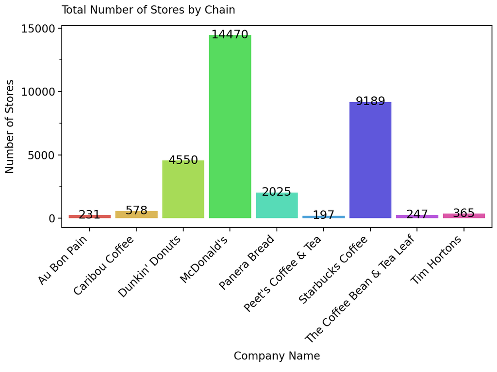

```
<Figure Size: (640 x 480)>
```

```python
# 1. Total Number of Stores by Chain
plot1 = (
    ggplot(stores_by_chain, aes(x='Company Name', y='Store Locations', fill='Company Name')) +
    geom_bar(stat='identity') +
    geom_text(aes(label='Store Locations'), nudge_y=0.5, color='black') +
    labs(title='Total Number of Stores by Chain', x='Company Name', y='Number of Stores') +
    theme_matplotlib() +
    theme(legend_position='none',
           axis_text_x=element_text(rotation=45, hjust=1))
)
plot1
```

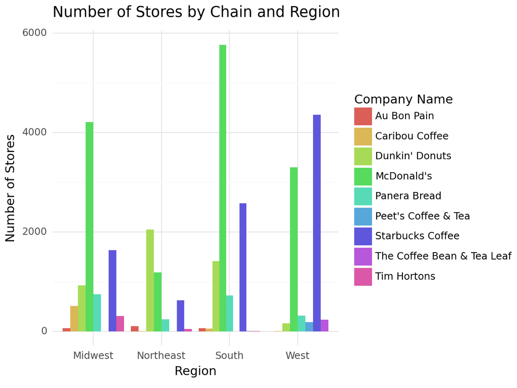

```
<Figure Size: (640 x 480)>
```

```python
# 2. Number of Stores by Chain and Region
stores_by_chain_region = coffee.groupby(['Company Name', 'region'])['Store Locations'].sum().reset_index()

plot3 = (
    ggplot(stores_by_chain_region, aes(x='region', y='Store Locations', fill='Company Name')) +
    geom_bar(stat='identity', position='dodge') +
    labs(title='Number of Stores by Chain and Region', x='Region', y='Number of Stores') +
    theme_minimal() +
    theme(legend_position='right')
)
plot3
```

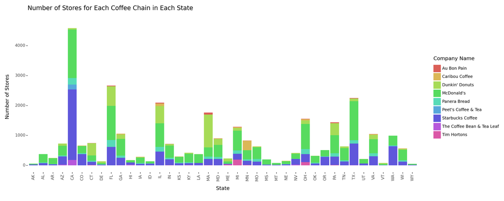

```
<Figure Size: (1500 x 600)>
```

```python
grouped_coffee = coffee.groupby(['State Names', 'Company Name'])['Store Locations'].sum().reset_index()

# Create a bar plot showing the number of stores for each coffee chain in each state
plot_state = (ggplot(grouped_coffee, aes(x='State Names', y='Store Locations', fill='Company Name')) +
              geom_bar(stat='identity', position='stack') +
              labs(title='Number of Stores for Each Coffee Chain in Each State',
                   x='State',
                   y='Number of Stores') +
              theme_tufte()+
              theme(figure_size=(15, 6),
                    axis_text_x=element_text(angle=90)))
plot_state
```

**Interpretation:** Starbucks and McDonald’s clearly have a stronghold in the coffee market across the United States, as evidenced by their widespread presence in nearly all regions and states, and their substantial revenue figures. This dominance is a reflection of their expansive number of outlets nationwide.Interestingly, despite having a lower overall store count compared to Starbucks and McDonald’s, Dunkin’ Donuts emerges as the premier coffee distributor in the Northeast region, particularly in Massachusetts where it holds a significant market share

A nuanced comparison between McDonald’s and Starbucks reveals some regional variations in their prevalence. Starbucks has carved out a slightly more dominant position in California, whereas McDonald’s is the undisputed leader in Texas. This pattern extends to regional dominance, with Starbucks being the predominant coffee chain in the West, and McDonald’s reigning supreme in the South.

The data paints a fascinating picture of the regional tastes and market forces that dictate the prominence of these coffee chains in different parts of the country. It is evident that while the total number of stores is a substantial factor in their market presence, regional and state-specific dynamics also play a pivotal role in shaping their market dominance.

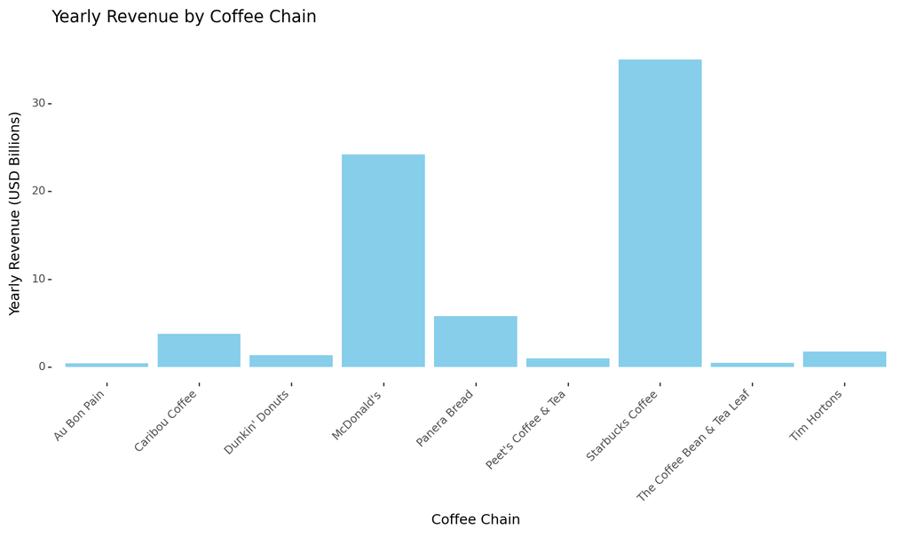

```
<Figure Size: (1000 x 600)>
```

```python
plot_revenue = (ggplot(coffee, aes(x='Company Name', y='Rev(USD Billions)')) +
                geom_bar(stat='identity', position='dodge', fill='skyblue') +
                labs(title='Yearly Revenue by Coffee Chain',
                     x='Coffee Chain',
                     y='Yearly Revenue (USD Billions)') +
                theme_tufte()+
                theme(figure_size=(10, 6),
                      axis_text_x=element_text(angle=45, hjust=1)))

# Display the plot
plot_revenue
```

**Interpretation:** Starbucks and McDonald’s, with their vast number of stores spread across a multitude of states, naturally boast substantial revenue figures that are reflective of their extensive reach and market penetration. On the other hand, Peet’s Coffee, despite being a renowned brand, has a significantly more localized presence, with an overwhelming majority of its stores situated in California. This regional concentration inherently impacts its overall revenue, resulting in figures that are comparatively lower than the more widely distributed Starbucks and McDonald’s. The visual depiction of store locations by state clearly highlights Peet’s Coffee’s predominant focus on California, thereby providing a clear and comprehensive explanation for its relatively modest revenue in comparison to its competitors.